# Challenge 7: Incorporating Multiple Inputs

Functions + Fish

Author

Christopher Hawkins

```r
library(tidyverse)
library(here)

data <- read.csv(here("data", "BlackfootFish.csv"))
```

## Condition Index

A frequently used measurement for fish health is a condition index [(Wikipedia article)](https://en.wikipedia.org/wiki/Condition_index_in_fish). The following simple equation can be used to calculate the approximate condition index of a fish:

$$\text{condition index} = \frac{weight}{length^3} \times 100$$

**1. There are specific units required for the calculation of a condition index – length must be in centimeters and weight must be in grams. The weight data for the Blackfoot River fish were collected in grams; the length data were collected in millimeters. Transform the length data to the correct units.**

```r
data <- data |>
  mutate(length = length / 10)
```

**2. Collecting data of this sort can be very messy! Write a function that will replace unlikely `length` and `weight` measurements with `NA`. Your function should accept at least three inputs:**

- **a vector of measurements,**
- **the minimum reasonable value,**
- **the maximum reasonable value.**

**If a value falls outside these bounds, you should replace it with an `NA`.**

**Tip**

If you are struggling with the structure of your function, I would suggest reading the [Mutating Function](https://r4ds.hadley.nz/functions.html#mutate-functions) from R4DS.

```r
replace_unlikely_values <- function(measurements, min_value, max_value) {
  # Use case_when to replace values outside bounds with NA
  measurements <- case_when(
    measurements < min_value | measurements > max_value ~ NA_real_,
    TRUE ~ measurements
  )
  return(measurements)
}
```

**3. After consulting the [Montana Record Table](https://fwp.mt.gov/fish/anglingData/records) for the four species of trout included in these data, I have conjectured that it is unlikely to have measurements for fish below 5 cm and above 80 cm in length or below 10 g and above 4,000 g in weight. Use your function to modify the `length` and `weight` columns of the `fish` dataset based on my cutoffs.**

```r
data <- data |>
  mutate(
    length = replace_unlikely_values(length, 5, 80),
    weight = replace_unlikely_values(weight, 10, 4000)
  )
```

**3. Write a function to calculate the condition index of a fish, given inputs of weight and length.**

**Warning**

Consider whether you will write a function that works with vectors (accepting vectors as inputs) or a function that works with data frames (accepting a dataset and variable names as inputs)!

```r
calculate_condition_index <- function(weight, length) {
  # Calculate condition index using the given formula
  condition_index <- (weight / (length^3)) * 100
  return(condition_index)
}
```

**4. Make a thoughtful visualization of how fish conditions have varied over the duration of this study.**

**To be thoughtful…**

… you need to use at least a third variable!

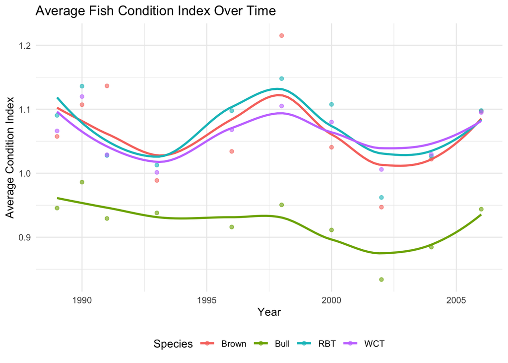

```r
average_condition_index <- data |>
  mutate(condition_index = calculate_condition_index(weight, length)) %>%
  group_by(species, year) %>%
  summarize(average_condition_index = mean(condition_index, na.rm = TRUE), .groups = "drop")

# Step 2: Create the plot
ggplot(average_condition_index, mapping = aes(x = year, y = average_condition_index, color = species)) +
  geom_point(alpha = 0.6) +            # Scatter plot for individual points
  geom_smooth(method = "loess", se = FALSE, aes(color = species)) +  # Smoothing curve by species
  labs(
    title = "Average Fish Condition Index Over Time",
    x = "Year",
    y = "Average Condition Index",
    color = "Species"
  ) +
  theme_minimal() +
  theme(legend.position = "bottom")
```